# Spatial species turnover maintains high diversities in a tree assemblage of a fragmented tropical landscape - Carneiro - 2016 - Ecosphere - Wiley Online Library

[Ecosphere](https://esajournals.onlinelibrary.wiley.com/journal/21508925)

[Volume 7, Issue 10](https://esajournals.onlinelibrary.wiley.com/toc/21508925/2016/7/10) e01500

[figure not shown]

Article

Open Access

# Spatial species turnover maintains high diversities in a tree assemblage of a fragmented tropical landscape

[Magda Silva Carneiro](https://esajournals.onlinelibrary.wiley.com/action/doSearch?ContribAuthorRaw=Carneiro%2C+Magda+Silva),

[Caroline Cambraia Furtado Campos](https://esajournals.onlinelibrary.wiley.com/action/doSearch?ContribAuthorRaw=Campos%2C+Caroline+Cambraia+Furtado),

[Flavio Nunes Ramos](https://esajournals.onlinelibrary.wiley.com/action/doSearch?ContribAuthorRaw=Ramos%2C+Flavio+Nunes),

[Flavio Antonio Maes dos Santos](https://esajournals.onlinelibrary.wiley.com/action/doSearch?ContribAuthorRaw=Dos+Santos%2C+Flavio+Antonio+Maes),

First published: 19 October 2016

https://doi.org/10.1002/ecs2.1500

Citations: 5

Corresponding Editor: Debra P. C. Peters.

## Abstract

The fragmentation process has many negative effects on communities, particularly for plants. This process can generate two distinct scenarios: homogenization of species composition, due to assemblage nestedness, or flora differentiation, due to spatial species turnover. The aim of this study was to answer the following questions: (1) Is the tree canopy and understory community of a highly fragmented landscape (9% of forest cover) the result of species nestedness or turnover? (2) Is the pattern of additive partitioning of diversity similar between the understory and canopy tree communities? and (3) Are landscape characteristics responsible for diversity partitioning of the tree assemblage? The studied area has low remaining forest coverage (~9%), caused by deforestation that started in the 18th century, and a very heterogeneous matrix around forest patches. Within this landscape context, we hypothesized that the tree assemblage (both canopy and understory strata) in the studied fragments would be homogeneous, as a consequence of a nested subset. The study was carried out in nine fragments of submontane semideciduous Atlantic Forest. All individuals with a height >1 m in 10 (200 m<sup>2</sup>) plots in each studied fragment were sampled, measured, and divided into two strata (canopy and understory individuals). The study found that the high beta diversity among plots and among fragments in both strata was due to species turnover (avoiding species homogenization) and that the landscape characteristics tested were not responsible for this result. These fragments present many rare and exclusive species and are not dominated by only a few species. In this scenario, it is necessary to conserve as many fragments as possible to protect most of tree assemblage because each fragment has a unique species composition.

## Introduction

Currently, most of the remaining forests are located in human-modified landscapes and are small, disconnected fragments in anthropogenic matrices (Melo et al. 2013). The fragmentation process is considered one of the major threats to tropical biodiversity and may cause changes in the structure and composition of communities over time (Laurance et al. 2011 for revision). For plant communities, fragmentation may generate two different scenarios: species homogenization by nestedness or floristic differentiation by species turnover (Baselga 2010, Arroyo-Rodríguez et al. 2013, Hernández-Ruedas et al. 2014). Nestedness occurs when communities from poor sites are subsets of richer ones, reflecting non-random extinction. While spatial species turnover refers to the replacement of some species by different ones (Chase and Myers 2011) and is a consequence of environmental sorting or spatial and historical constraints (Baselga 2010).

The homogenization hypothesis predicts that fragments inserted in the same human-modified landscape, with similar abiotic and biotic pressures (environmental conditions, matrix type), will have similar dynamics and trajectory of species composition change (Laurance et al. 2007). Sensitive species will be extinguished locally, and the greater the impact and stress on the fragment, the more species will disappear in an orderly way, creating a nested community (Laurance et al. 2007). Thus, the species composition in less diverse fragments will be a subset of the species composition from the richest one (Wright et al. 1998, Baselga 2010), and, over time, the fragments become homogeneous. On the contrary, floristic differentiation occurs in fragments that are suffering from different environmental pressures and/or is located in a heterogeneous landscape (Laurance et al. 2007). In this scenario, the initial flora difference is amplified over time due to differences in the disturbances (Laurance et al. 2007). The original heterogeneity, combined with landscape heterogeneity and the different types of disturbances, generates communities with different floristic compositions in each remnant, and consequently no nested communities (Baselga 2010). This heterogeneity generates dynamic fragments, where there is no orderly species extinction, but a replacement of some original species with other species (Wright and Reeves 1992, Baselga 2010).

A recent study of tropical landscapes in Mexico (Arroyo-Rodríguez et al. 2013) found flora homogenization in fragments in areas with high deforestation levels. These results put into question the diversity maintenance in these anthropogenic landscapes over time. However, other studies (Santos et al. 2006, Hernández-Ruedas et al. 2014) show that floristic homogenization is not always predominant and that small fragments inserted in human-modified landscapes can retain large levels of biodiversity. The justification for these different results is that the trajectory of fragments inserted in human-modified landscapes depends on many factors, such as matrix type, forest cover, distance between fragments, disturbance history, and fragmentation age (Santos et al. 2006, Laurance et al. 2007, Arroyo-Rodríguez et al. 2013, Hernández-Ruedas et al. 2014). Tree assemblage within close fragments, inserted in landscapes with high forest coverage and heterogeneous matrices, has a higher chance of exchanging pollen and seeds (Antongiovanni and Metzger 2005) and is less affected by edge effect (Mesquita et al. 1999). For these reasons, they are less likely to become homogeneous and have high conservation value (Hernández-Ruedas et al. 2014).

An efficient way to understanding the floristic homogenization and differentiation phenomena is through additive partitioning of diversity (Laurance et al. 2007, Baselga 2010). Fragments with homogenized composition present low beta diversity, both within and among fragments, while beta diversity is high among fragments with floristic differentiation (Laurance et al. 2007, Arroyo-Rodríguez et al. 2013). Through statistical analyses, it is also possible and important to decompose the beta diversity in species nesting and turnover (Baselga 2010), because the conservation implications for each result are different. In nested subset scenarios, the implication for conservation is to preserve the most diverse fragments, as the remaining fragments are smaller subsets with fewer, more tolerant species (Wright and Reeves 1992, Laurance et al. 2007). For the floristic differentiation scenario, biodiversity conservation depends on protecting the largest possible number of fragments, because each one has a unique species composition and is therefore complementary to the landscape gamma diversity (Wright and Reeves 1992, Laurance et al. 2007).

There are few empirical studies that have quantified the spatial variation in the beta diversity based on tree nesting and turnover components; there are two studies about temperate European forests (Baeten et al. 2012, Kouba et al. 2014) and one about African coastal forests (Olivier and van Aarde 2014). This study is the first for tropical forest fragments. Beta diversity, even more than alpha diversity, gives a broader view of regional biodiversity. In addition, it allows conservation status (high beta diversity within fragments) and environmental disturbance (low beta diversity within fragments) to be assessed (Condit et al. 2002). In this context, the aim of this study was to apply the additive partitioning of diversity (as proposed by Laurance et al. 2007), in semideciduous forest fragments, by quantifying the proportion of the diversity that resulted from nesting and turnover processes on a tree assemblage (Baselga 2010). More specifically, we asked the following questions: (1) Is the pattern of additive partitioning of diversity of the tree assemblage similar between the understory and canopy strata? (2) Did the tree assemblage pattern in the canopy and understory strata result from species nesting or replacement turnover? and (3) Are landscape characteristics responsible for diversity partitioning of the tree assemblage?

## Methods

### Study area

Table 1. Information (popular name, area, location) analyzed from nine seasonal semideciduous forest fragments in southeastern Brazil

[output not shown]

- <sup>*a*</sup> Cover: Percentage of forest cover.

The climate is classified as Cwa (with a dry winter and temperate summer), the average temperature is 16.9°C in the winter and 21.5°C in the summer, and the average precipitation is 26 mm in the winter and 290 mm in the summer (Alvares et al. 2014). The region has elevations ranging from 720 to 1350 m, and a predominantly undulating relief associated with hills and mountains. The region has only about 9% native forest habitat, and the most common matrix types are pastures (51%), and permanent (mainly coffee—17%) and temporary (mainly sugar cane and corn—7%) crops (Olivetti et al. 2015). The region excelled as a coffee producer in the 19th and 20th centuries. However, it was used for traditional agropastoral practices in the 18th and early 19th centuries (Castilho 2009).

### Statistical analysis

Taxonomic richness, bootstrap estimator, the Shannon–Wiener index, and Pielou's evenness were used to evaluate the community diversity (Magurran 2004). Diversity profiles were used to evaluate and compare the diversity of species among fragments (Tóthmérész 1995). Each diversity index differs in the mass given to rare species, and using the diversity profiles, it is possible to observe whether the difference in diversity among fragments is due to rare or abundant species (Melo 2008). Diversity profiles were calculated with Hill's Series in the software PAST (Hammer and Harper 2014). In this series, when α = 0, Hill's number = number of species (*S*), when α = 1, Hill's number = exp (*H*′), and when α = 2, Hill's number = inverse of Simpson's dominance index (1/*D*).

The additive partitioning of species diversity was used to verify how the variation in the diversity occurs at different scales (1) among plots within the same fragment and (2) among different fragments (Crist et al. 2003, Anderson et al. 2011). In the additive partitioning of species diversity (here calculated by species richness), the regional or total diversity (γ) is divided into α and β components that are expressed in the same unit. The total species richness (γ) of a set of samples is divided at the richness average into the samples (α) and richness average absent in each sample (β). That way, γ = α + β1 + β2 + … β*n*, where *n* = number of levels, and β*n* = α*n* + 1 − α*n* (Crist et al. 2003). The average diversity in the plots (level 1) and in the fragments (level 2) was calculated as a component of total diversity, to verify the spatial variation in the diversity. This observed diversity was compared with a null distribution model of diversity consisting of the mean diversity obtained through 1000 randomizations. The 1000 randomizations ensure the expected diversity of the distribution of individuals is random. The expected diversity was calculated with the software Partition (Crist et al. 2003). We used the additive approach because, unlike the multiplicative, the components of diversity remain in the same sample unit independent of the scale. Additionally, it is possible to calculate the relative contribution of alpha diversity and beta diversity for gamma diversity at different scales (Lande 1996, Crist et al. 2003).

Presence/absence matrices and the Sorensen dissimilarity index were used for the decomposition of beta diversity in nestedness and turnover components for two scales (plots and fragments). This index ranges from 0 (completely similar) to 1 (completely dissimilar). Subsequently, we partitioned the total dissimilarities (*B*<sub>SOR</sub>) in the proportions generated by nestedness (*B*<sub>NES</sub>) and turnover (*B*<sub>SIM</sub>), where *B*<sub>SOR</sub> = *B*<sub>NES</sub> + *B*<sub>SIM</sub> (Baselga 2010). These analyses were carried out in R (R Development Core Team 2007) using the functions “beta-multi.R” in package “betaparte.” A recent study (Baselga and Leprieur 2015) showed that with this method the nestedness-resultant component accounts only for richness differences derived from nested patterns, while in other methods richness difference dissimilarity accounts for all kinds of richness differences. Moreover, in the method proposed by Baselga (2010) the replacement component is independent of richness difference.

A partial redundancy analysis (Rao 1964) was performed in order to verify whether the landscape configurations, COVER and MATRIX, are able to explain the variation in the beta diversity among fragments. For this analysis, we used two data matrices, a matrix with the number of individuals per species in each fragment and a matrix with the landscape parameters. The calculation of how landscape parameters selected are able to explain the variation in the beta diversity among the fragments was carried out according to Legendre et al. (2005) using the vegan package (Oksanen et al. 2007) available in the software R (R Development Core Team 2007). The significance of the percentage of explanation was evaluated according to the permutation method described by Legendre and Legendre (1998), performing 9999 permutations.

## Results

### Canopy stratum

Table 2. Number of families (*F*), sampled species (*S*), estimated species by bootstrap (ES), number of rare species (only one individual) (RS), number of individuals (*I*), Shannon's diversity index (*H*′), and Pielou's evenness index (*J*′) from nine sites of seasonal semideciduous forest in southeastern Brazil

| Fragments | DBH (cm) | *F* | *S* | ES | RS (%) | *I* | *H*′ | *J*′ |
| --- | --- | --- | --- | --- | --- | --- | --- | --- |
| 1—Porto | ≥5 | 24 | 57 | 69.77 | 25 (43.85) | 210 | 3.54 | 0.88 |
|  | ≤5 | 38 | 103 | 124.81 | 46 (44.66) | 848 | 3.18 | 0.67 |
| 2—Gaspar Lopes | ≥5 | 28 | 85 | 105.26 | 46 (54.12) | 222 | 4.00 | 0.90 |
|  | ≤5 | 45 | 127 | 147.29 | 34 (26.77) | 1154 | 3.83 | 0.79 |
| 3—M | ≥5 | 24 | 68 | 81.62 | 27 (39.71) | 280 | 3.61 | 0.86 |
|  | ≤5 | 30 | 102 | 119.34 | 31 (30.39) | 658 | 3.94 | 0.85 |
| 4—I | ≥5 | 22 | 56 | 68.17 | 23 (41.07) | 257 | 3.28 | 0.82 |
|  | ≤5 | 34 | 99 | 117.69 | 34 (34.34) | 779 | 3.24 | 0.71 |
| 5—Paraiso | ≥5 | 29 | 58 | 70.34 | 26 (44.82) | 210 | 3.42 | 0.84 |
|  | ≤5 | 32 | 87 | 103.15 | 37 (42.53) | 417 | 3.75 | 0.84 |
| 6—São José | ≥5 | 18 | 39 | 46.54 | 14 (35.89) | 169 | 3.17 | 0.87 |
|  | ≤5 | 34 | 83 | 98.04 | 31 (37.35) | 612 | 3.25 | 0.74 |
| 7—N | ≥5 | 22 | 52 | 63.58 | 24 (46.15) | 230 | 3.17 | 0.80 |
|  | ≤5 | 32 | 93 | 111.65 | 40 (43.01) | 517 | 3.80 | 0.84 |
| 8—Cemiterio | ≥5 | 27 | 66 | 82.72 | 36 (54.54) | 181 | 3.59 | 0.86 |
|  | ≤5 | 31 | 80 | 96.85 | 35 (43.75) | 492 | 3.27 | 0.75 |
| 9—Matão | ≥5 | 28 | 83 | 101.37 | 40 (48.19) | 226 | 4.03 | 0.91 |
|  | ≤5 | 43 | 153 | 183.51 | 62 (40.52) | 876 | 4.15 | 0.82 |
| Total | ≥5 | 48 | 205 | 239.05 | 56 (27.31) | 1985 | 4.38 | 0.82 |
|  | ≤5 | 58 | 272 | 304.52 | 62 (22.80) | 6353 | 4.26 | 0.76 |

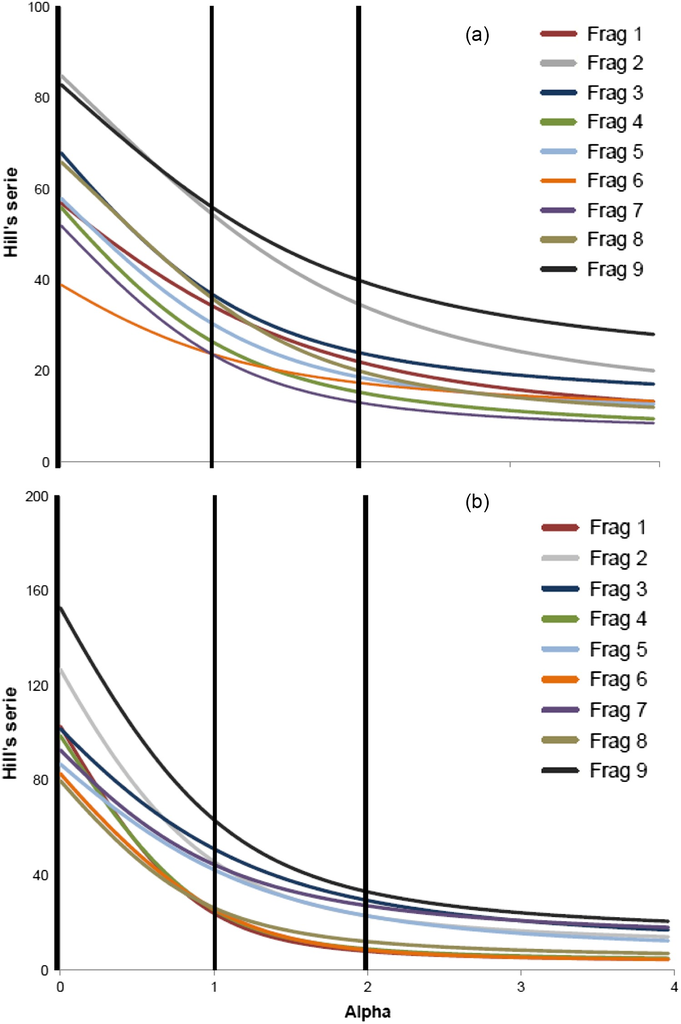

**Figure 1**

Diversity profiles for the nine fragments using Hill's Series. When the parameter α = 0, the diversity value is equal to the number of species in the sample. For α tending to 1, the diversity value is equivalent to Shannon's index (natural base). For α = 2, the value is the same as obtained using the inverse of Simpson's index (1/*D*). (a) Individuals with DAP ≥ 5.0 cm. (b) Individuals with DAP ≤ 5.0 cm.

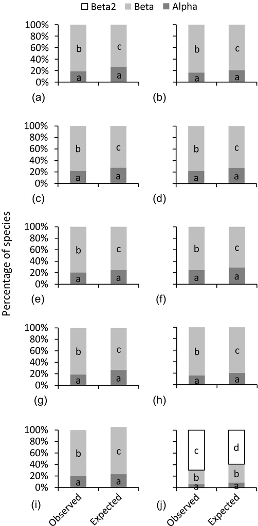

**Figure 2**

Additive partition of species diversity for species with DAP ≥ 5.0 cm. Alpha is the average richness within the plots. Beta is the average richness absent in the plots. Beta2 is the average richness absent in the fragments. The sum of α and β components results in gamma diversity of each fragment. The sum of α, β, and β2 components results in gamma diversity of the region. Different letters indicate observed values significantly different than the expected value, if the distribution were random. (a) Additive partition of species diversity in fragment 1 (*p*<sub>α</sub> = 0.99, *p*<sub>β</sub> = 0.001). (b) Additive partition of species diversity in fragment 2 (*p*<sub>α</sub> = 0.99, *p*<sub>β</sub> = 0.001). (c) Additive partition of species diversity in fragment 3 (*p*<sub>α</sub> = 0.99, *p*<sub>β</sub> = 0.001). (d) Additive partition of species diversity in fragment 4 (*p*<sub>α</sub> = 0.99, *p*<sub>β</sub> = 0.001). (e) Additive partition of species diversity in fragment 5 (*p*<sub>α</sub> = 0.99, *p*<sub>β</sub> = 0.001). (f) Additive partition of species diversity in fragment 6 (*p*<sub>α</sub> = 0.99, *p*<sub>β</sub> = 0.001). (g) Additive partition of species diversity in fragment 7 (*p*<sub>α</sub> = 0.99, *p*<sub>β</sub> = 0.001). (h) Additive partition of species diversity in fragment 8 (*p*<sub>α</sub> = 0.99, *p*<sub>β</sub> = 0.001). (i) Additive partition of species diversity in fragment 9 (*p*<sub>α</sub> = 0.99, *p*<sub>β</sub> = 0.001). (j) Additive partition of species diversity in region (all fragments) (*p*<sub>α</sub> = 0.99, *p*<sub>β</sub> = 0.99, *p*<sub>β2</sub> = 0.001). Different letters indicate statistical difference.

### Understory stratum

The total species richness based on bootstrap estimator, in the nine sites, remained high (304.5), as well as Shannon's diversity index (4.26 nats/ind) and Pielou's evenness index (0.76) (Table 2). Frequent species, those occurring in all fragments, represent 3.7% of the total richness and 33% of the total individuals sampled. On the other hand, species that occur in only one fragment represent 34.2% (93) of the total species and 2.4% of the individuals.

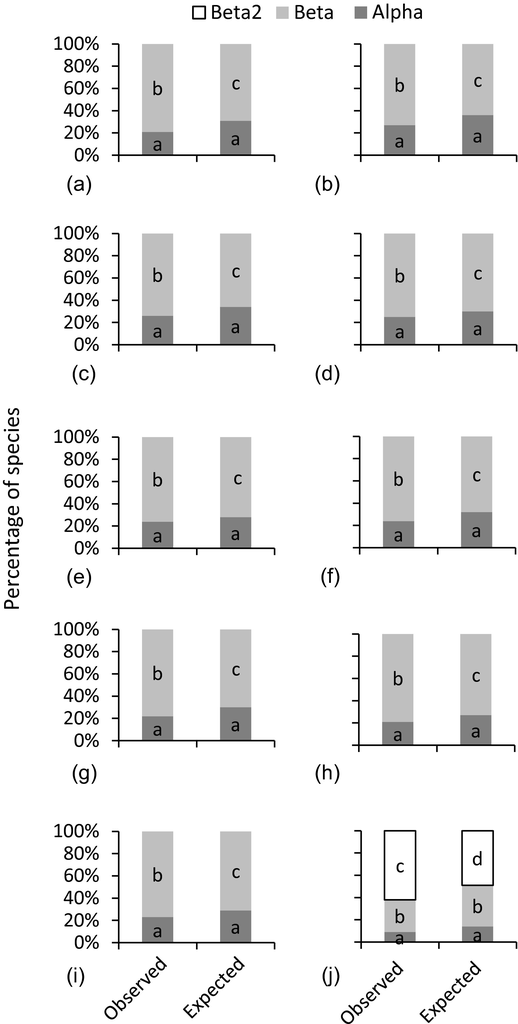

**Figure 3**

Additive partition of species diversity for species with DAP ≤ 5.0 cm. Alpha is the average richness within the plots. Beta is the average richness absent in the plots. Beta2 is the average richness absent in the fragments. The sum of α and β components results in the gamma diversity of each fragment. The sum of α, β, and β2 components results in the gamma diversity of the region. Different letters indicate observed values significantly different than the expected value, if the distribution were random. (a) Additive partition of species diversity in fragment 1 (*p*<sub>α</sub> = 0.99, *p*<sub>β</sub> = 0.001). (b) Additive partition of species diversity in fragment 2 (*p*<sub>α</sub> = 0.99, *p*<sub>β</sub> = 0.001). (c) Additive partition of species diversity in fragment 3 (*p*<sub>α</sub> = 0.99, *p*<sub>β</sub> = 0.001). (d) Additive partition of species diversity in fragment 4 (*p*<sub>α</sub> = 0.99, *p*<sub>β</sub> = 0.001). (e) Additive partition of species diversity in fragment 5 (*p*<sub>α</sub> = 0.99, *p*<sub>β</sub> = 0.001). (f) Additive partition of species diversity in fragment 6 (*p*<sub>α</sub> = 0.99, *p*<sub>β</sub> = 0.001). (g) Additive partition of species diversity in fragment 7 (*p*<sub>α</sub> = 0.99, *p*<sub>β</sub> = 0.001). (h) Additive partition of species diversity in fragment 8 (*p*<sub>α</sub> = 0.99, *p*<sub>β</sub> = 0.001). (i) Additive partition of species diversity in fragment 9 (*p*<sub>α</sub> = 0.99, *p*<sub>β</sub> = 0.001). (j) Additive partition of species diversity in region (all fragments) (*p*<sub>α</sub> = 0.99, *p*<sub>β</sub> = 0.99, *p*<sub>β2</sub> = 0.001). Different letters indicate statistical difference.

## Discussion

In the present study, we found that the high beta diversity within and among fragments in both strata was due to species turnover (avoiding species homogenization). The tested landscape characteristics did not influence the diversity partition of the tree assemblage of both strata. The partition of the diversity of the tree assemblage from the understory and canopy strata confirms the good conservation condition of the fragmented landscape studied and suggests that these fragments are able to maintain diversity over time. Most of the tree studies were not included in the canopy stratum (the only stratum studied in most other works); however, they are important to consider (Salles and Schiavini 2007) because these individuals are more sensitive (smaller, thinner, and younger individuals) and may have been recruited after the fragmentation process. The results for the understory stratum to recent disturbances are more accurate than the canopy stratum, as adult trees have long life cycles and could have been established before the fragmentation process, while most of the life cycle stages of the plants from the understory stratum happened during or after fragmentation (Martinez-Ramos and Alvarez-Buylla 1998). In this way, it is possible to predict the change in the community structure over time.

It was expected that smaller and isolated fragments, inserted in a landscape with low forest coverage and in anthropogenic matrices, would be in a process of floristic homogenization. In other words, the tree assemblage would be slowly dominated by tolerant species and missing more sensitive species (Laurance et al. 2007, Arroyo-Rodríguez et al. 2013). However, despite the studied landscape showing all these characteristics, the tree assemblage in the fragments is not in a homogenization process. On the contrary, the tree assemblage has high beta diversity and alpha diversity while the diversity profile shows that the diversity is mainly due to a large number of rare species. In addition, a previous study in the same area showed that these fragments still preserve high species diversity and richness and endangered species. We hypothesize that these unexpected results were from two main factors: the fragment heterogeneity and the landscape context where the fragments occur.

Local beta diversity patterns can be attributed to niche structure, biological interactions, and environmental characteristics (Arroyo-Rodríguez et al. 2013). More heterogeneous environments present more resources and conditions, which would result in a greater number of niches, supporting greater diversity of species than simpler ones (MacArthur and MacArthur 1961). Forest fragments, even small ones, can present different internal characteristics, such as the presence or absence (and/or quantity) of streams, gaps, and/or slopes, which create different micro-environments that could be occupied by different species, increasing the diversity (Chávez and Macdonald 2012, Sabatini et al. 2014). In fact, the studied fragments presented different characteristics among them, such as the presence or absence of streams, slope degrees, and different matrix types, which can generate intrinsic heterogeneity (M. S. Carneiro, *personal observation*). Another aspect of the study, reinforcing this hypothesis, is that high beta diversity within the fragments is mainly due to species turnover and not to richness nestedness, contrary to expectations generated by Laurance et al. (2007). One of the main factors responsible for species turnover is a heterogeneous environment (Wright et al. 1998). This result indicates that the differences in species composition among plots and among fragments are generated by different abiotic and biotic conditions within fragments or by different disturbance histories (Gaston et al. 2007, Baeten et al. 2012), and not by ordered loss of species. A study in a temperate forest reserve in Europe (Baeten et al. 2012) found similar results to the present study and attributed the high species turnover to heterogeneity of environmental conditions within the reserve. Our results show that even forest fragments located in human-modified landscapes can preserve some heterogeneous environmental conditions.

The second factor that could explain the floristic differentiation and high species turnover is the landscape context. Although we did not find a relationship between diversity partition and forest or matrix (pasture, sugar cane, and coffee) coverage, other landscape characteristics (not tested by us) could influence diversity partition. We suggest future studies test this relationship in fragmented landscapes with species turnover and other landscape characteristics. For example, the studied fragments are inserted in a more familiar agricultural system that, although commercial, is small scale with little mechanization. Additionally, more than one crop type is produced in the landscape, mainly coffee and sugar cane, and there are pastures with some isolated trees (Gonçalves 2015, Olivetti et al. 2015, Vergne 2015). Studies show that in landscapes where there are trees in pastures (Lindborg et al. 2014) and traditional agriculture (without mechanization) (Karp et al. 2012), the diversity and the plant species turnover are greater. Moreover, an attenuated edge effect could occur in landscapes with more heterogeneous and less managed matrices (Mesquita et al. 1999). Edge effect is one of the major factors leading to loss of biodiversity in forest fragments (Laurance and Peres 2006 for review). When this effect is softened, it is expected that diversity could be maintained or that species loss would occur slowly, avoiding the fragment homogenization (Hernández-Ruedas et al. 2014). The matrix heterogeneity in the present study could also contribute to the tree species turnover within and among areas (Fahrig et al. 2011). Another consideration based on our results is that some trees could have been recruited before and others after the fragmentation process, which would leave a confounding factor in the statistical analysis because only the trees recruited after fragmentation would have been influenced by the forest and matrix cover. This characteristic could explain the lack of a relationship between the tested landscape characteristics and the tree assemblage process. Tree assemblages have a delay in response to the fragmentation processes because they are long living (Helm et al. 2006, Vellend et al. 2006). Therefore, we suggest that future studies test whether the turnover in landscapes with forest fragmentation is due to our two hypotheses explained above: (1) the fragment heterogeneity and (2) the landscape context where the fragments occur.

Studies about beta diversity are relatively recent. The first work to verify beta diversity in tropical forests trees was published in 2002 (Condit et al. 2002). Beta diversity is more important than alpha diversity for biodiversity conservation, because it considers not only the diversity within a fragment, but also its variation in the region (Condit et al. 2002). This work is one of the first to investigate the homogenization process at local scales for tropical forest fragments and decompose the beta diversity in turnover and nestedness components. This decomposition is important because it has valuable implications for the conservation of diversity. When the fragments have a nested structure, the conservation of the richest fragment preserves all biodiversity in the region, as the other fragments are only a subset of the most diverse fragment. However, when there is large species turnover, as in the fragments studied, biodiversity conservation depends on the conservation of the largest possible number of fragments; as each fragment has a unique species composition, the loss of a fragment leads to the local extinction of exclusive species (Wright and Reeves 1992, Baselga 2010).

This study shows that even in a human-modified landscape, the canopy and understory plant communities are not in a homogenization process. In addition, we show for the first time that beta diversity of tropical forest fragments is due to turnover and not to nesting. These results, in addition to practical implications, can help to: (1) understand the process of homogenization in tropical forest fragments; (2) show the importance of intrinsic heterogeneity and a landscape context for maintaining high beta diversity within the fragments; and (3) understand the processes responsible for beta diversity in fragmented environments. Further, because of the implications for conservation, we suggest that the additive partitioning of diversity and nested subsets calculations are incorporated into management and conservation plans. In addition, we especially suggest that fragments and landscape heterogeneity be preserved to maintain regional diversity.

## Acknowledgments

We thank Derek Felipe, Erlon Pimenta, André Carvalho, Marcela Alcantara e Bruno Roberto Ribeiro for help with the fieldwork, Hisaias Almeida for identifying the species, and Nathan Smith for correcting the English. This research was financially supported by a grant from the Coordenação de Aperfeiçoamento de Pessoal de Nível Superior (CAPES) awarded to Magda Silva Carneiro. The project was also supported by the Fundação de Amparo a Pesquisa do Estado de Minas Gerais (FAPEMIG)/Vale Company (RDP-00104-10) and the Conselho Nacional de Desenvolvimento Cientifico e Tecnológico (CNPq) (472250/2010-8 and 306595/2014-1).

## Citing Literature

[figure not shown]

[Volume7, Issue10](https://esajournals.onlinelibrary.wiley.com/toc/21508925/2016/7/10)

October 2016

e01500